# Data science per psicologi - demo 13.02

Corrado Caudek

2022-03-24

```r
suppressPackageStartupMessages({
  library("here")
  library("tidyverse")
  library("scales")
  library("bayesplot")
  library("gghighlight")
})

theme_set(bayesplot::theme_default(base_size = 12))
bayesplot::color_scheme_set("gray")
set.seed(84735)

knitr::opts_chunk$set(
  collapse = TRUE,
  tidy = 'styler',
  fig.width = 6,
  fig.asp = 0.618 # 1 / phi
)
```

# Funzione gaussiana

Una funzione gaussiana è una funzione della seguente forma:

$$f(x) = \frac{1}{\sigma\sqrt{2\pi}}
e^\left( -\frac{1}{2}\left(\frac{x-\mu}{\sigma}\right)^{\!2}\,\right)$$

dove $e$ (il numero di Eulero) è il numero irrazionale 2.7182818… (la base dei logaritmi naturali). Più convenientemente, la funzione viene scritta come

$$f(x) = \frac{1}{\sigma\sqrt{2\pi}}
\exp\left(
-\frac{1}{2}\left(\frac{x-\mu}{\sigma}\right)^{\!2}\,\right)$$

laddove $\mu$ e $\sigma$ sono i paramemtri della distribuzione.

In `R` la formula diventa:

```r
gauss <- function(x, mu, sigma) {
  1 / sqrt(2 * pi * sigma^2) * exp(-(x - mu)^2 / (2 * sigma^2))
}
```

L’area è unitaria, per qualsiasi valore $\mu$ e $\sigma$:

```r
area <- integrate(
  gauss,
  mu = 100,
  sigma = 15,
  lower = -Inf,
  upper = Inf
)$value
area
```

```
## [1] 1
```

```r
area <- integrate(
  gauss,
  mu = 0,
  sigma = 1,
  lower = -Inf,
  upper = Inf
)$value
area
```

```
## [1] 1
```

Il fatto che la distribuzione gaussiana dipende dai parametri $\mu$ e $\sigma$ significa che, al variare dei parametri, varia la forma della curva di densità: la variazione di $\mu$ trasla la curva di densità in maniera rigida sull’asse $\mathbb{R}$; la variazione di $\sigma$ allarga o appiattisce la curva di densità.

Disegnamo la funzione di densità usando, come parametri, $\mu$ = 100 e $\sigma$ = 15 – ovvero, specifichiamo la distribuzione del QI.

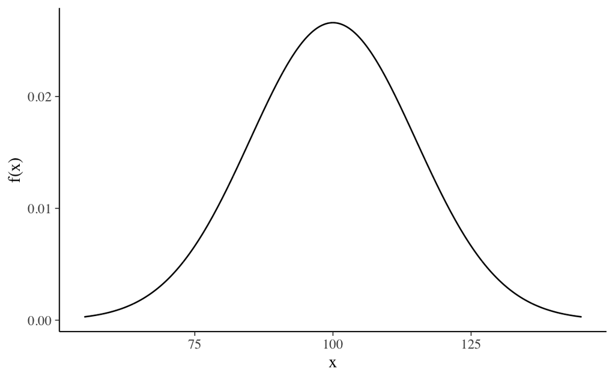

```r
mu <- 100
sigma <- 15
tibble(
  x = seq(55, 145, length.out = 1e3),
  y = gauss(x, mu, sigma)
) %>%
  ggplot(aes(x, y)) +
  geom_line() +
  labs(
    x = "x",
    y = "f(x)"
  )
```

Lo stesso risultato si ottene con

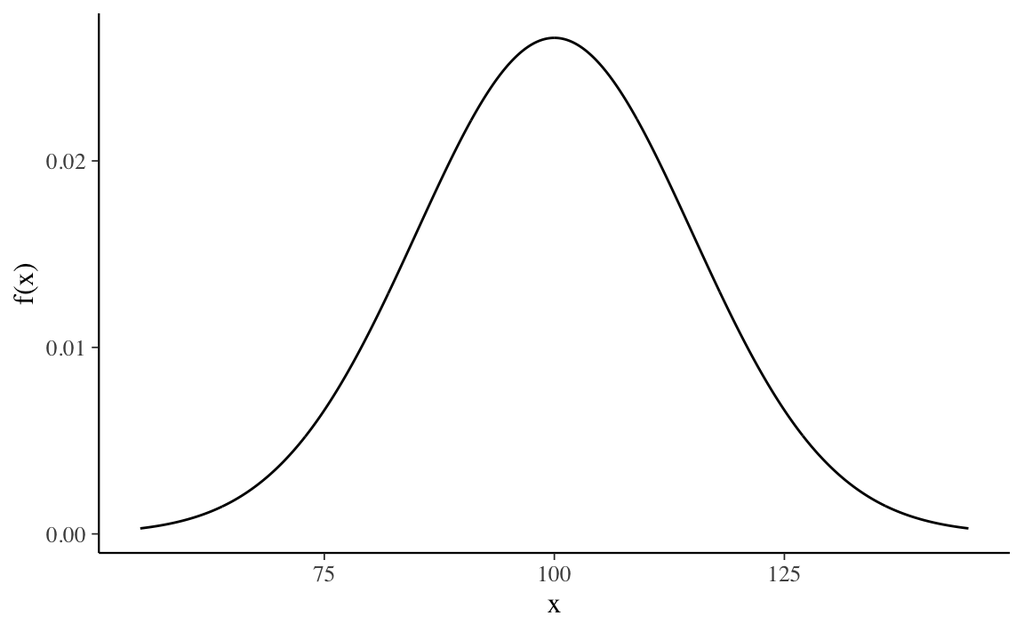

```r
mu <- 100
sigma <- 15
tibble(
  x = seq(55, 145, length.out = 1e3),
  y = dnorm(x, 100, 15)
) %>%
  ggplot(aes(x, y)) +
  geom_line() +
  labs(
    x = "x",
    y = "f(x)"
  )
```

## La funzione di ripartizione

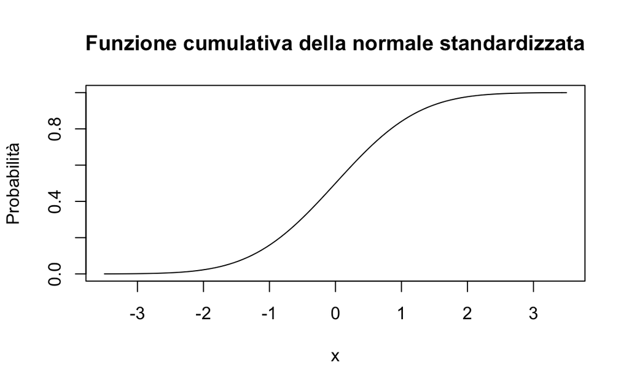

```r
curve(
  pnorm(x),
  xlim = c(-3.5, 3.5),
  ylab = "Probabilità",
  main = "Funzione cumulativa della normale standardizzata"
)
```

## Quantili e densità

Definiamo i seguenti quantili e calcoliamo la densità corrispondente per il caso della normale standardizzata:

```r
quants <- c(-1.96, 0, 1.96)
gauss(quants, mu = 0, sigma = 1)
```

```
## [1] 0.05844094 0.39894228 0.05844094
```

Lo stesso risultato si ottene con

```r
dnorm(quants, mean = 0, sd = 1)
```

```
## [1] 0.05844094 0.39894228 0.05844094
```

## La probabilità

Calcoliamo ora la probabilità che la variabile casuale $X \sim \mathcal{N}(\mu, \sigma)$ assuma valori in un determinato intervallo. Una tale probabilità corrisponde all’area sottesa alla funzione di densità nell’intervallo specificato.

Per fare un esempio, consideriamo il quoziente d’intelligenza, QI, perché sappiamo che è distribuito secondo la legge gaussiana con media 100 e deviazione standard 15, ovvero $QI \sim \mathcal{N}(\mu = 100, \sigma = 15)$.

Ci chiediamo qual è la probabilità che un individuo preso a caso abbia un QI $< 115$. Rispondere a tale domanda significa calcolare

$$P(\mbox{X} < 115), \quad \mbox{X} \sim \mathcal{N}(\mu = 100, \sigma
= 15).$$
Dato che la probabilità è l’area sottesa alla funzione di densità nell’intervallo specificato, il problema ci chiede di calcolare l’area sottesa alla funzione $\mathcal{N}(\mu = 100, \sigma = 15)$ nell’intervallo $[-\infty, 115]$.

Iniziamo evidenziando, in un grafico, l’area cercata:

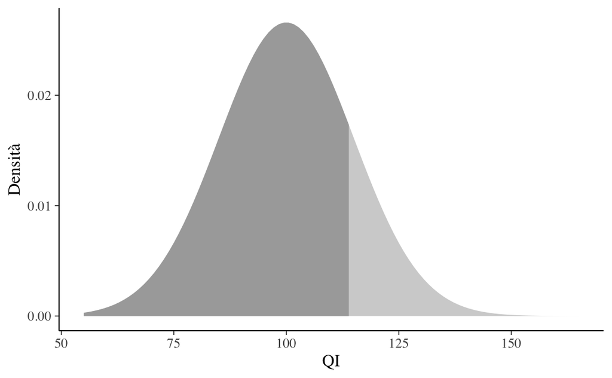

```r
tibble(
  x = seq(55, 165, length.out = 100)
) %>%
  mutate(
    y = dnorm(x, mean = 100, sd = 15)
  ) %>%
  ggplot(aes(x, y)) +
  geom_area(fill = "dark gray") +
  gghighlight(x < 115) +
  labs(
    x = "QI",
    y = "Densità"
  )
```

Il risultato cercato è

```r
integrate(
  gauss,
  mu = 100,
  sigma = 15,
  lower = -Inf,
  upper = 115
)
## 0.8413447 with absolute error < 3.8e-06
```

ovvero

```r
pnorm(115, mean = 100, sd = 15)
```

```
## [1] 0.8413447
```

Consideriamo ora l’area sottesa alla funzione di densità nell’intervallo $\mu \pm 1.96 \sigma$.

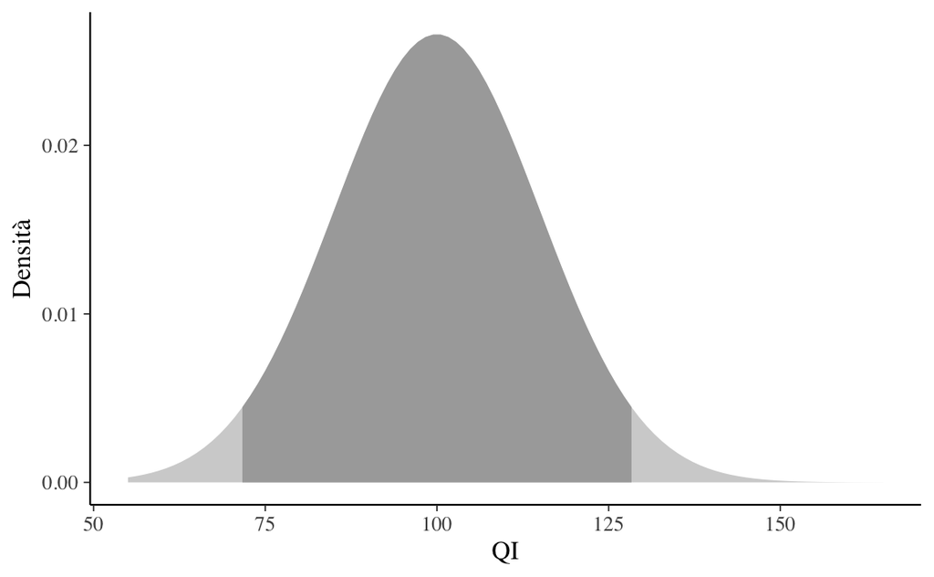

```r
tibble(
  x = seq(55, 165, length.out = 100)
) %>%
  mutate(
    y = dnorm(x, mean = 100, sd = 15)
  ) %>%
  ggplot(aes(x, y)) +
  geom_area(fill = "dark gray") +
  gghighlight(x > 100 - 1.96 * 15 & x < 100 + 1.96 * 15) +
  labs(
    x = "QI",
    y = "Densità"
  )
```

La probabilità cercata è

```r
integrate(
  gauss,
  mu = 100,
  sigma = 15,
  lower = 100 - 1.96 * 15,
  upper = 100 + 1.96 * 15
)
## 0.9500042 with absolute error < 1e-11
```

ovvero

```r
pnorm(100 + 1.96 * 15, 100, 15) - pnorm(100 - 1.96 * 15, 100, 15)
```

```
## [1] 0.9500042
```

## Il valore atteso

Il valore atteso di una variabile aleatoria continua $X$ è

$$\mathbb{E}(X) = \mu_X = \int x \,f(x) \,\operatorname {d}\!x.$$

Per calcolare il valore numerico dell’integrale con `R` definiamo la seguente funzione:

```r
g <- function(x) x * gauss(x, 100, 15)
```

Possiamo ora usare `integrate()` per trovare la soluzione che cerchiamo:

```r
EX <- integrate(
  g,
  lower = -Inf,
  upper = Inf
)$value
EX
```

```
## [1] 100
```

## La varianza

La varianza di una variabile aleatoria continua $X$ è
$$\mathbb{V}(X) = \sigma^2_X = \int_{\mathbb{R}} (x - \mu)^2 \, f(x)
\,\operatorname {d}\!x.$$
In `R` definiamo la funzione

```r
h <- function(x) x^2 * gauss(x, 100, 15)
```

e poi calcoliamo l’integrale

```r
VarX <- integrate(
  h,
  lower = -Inf,
  upper = Inf
)$value - EX^2
VarX
```

```
## [1] 225
```

La deviazione standard è

```r
sqrt(VarX)
```

```
## [1] 15
```

## Interpretazione dei parametri

In conclusione, la distribuzione gaussiana dipende da due parametri: $\mu$ e $\sigma^2$. Tali parametri corrispondono al valore atteso (cioè alla media) e alla varianza (cioè alla dispersione dei valori attorno al massimo della curva) della distribuzione.

## La funzione di quantile

La funzione di quantile specifica, per una probabilità data nella distribuzione di probabilità di una variabile casuale, il valore per cui la probabilità della variabile casuale sarà meno che o uguale a quella probabilità.

Per la distribuzione del quoziente di intelligenza, troviamo il valore del QI tale per cui solo il 10% della popolazione ha un valore maggiore:

```r
qnorm(0.90, mean = 100, sd = 15)
```

```
## [1] 119.2233
```

Troviamo il valore del QI tale per cui solo l’1% della popolazione ha un valore maggiore:

```r
qnorm(0.99, mean = 100, sd = 15)
```

```
## [1] 134.8952
```

Troviamo il valore del QI tale per cui il 90% della popolazione ha un valore maggiore:

```r
qnorm(0.10, mean = 100, sd = 15)
```

```
## [1] 80.77673
```